# 토지비율/생활만족도 별 범죄율 상관관계

```python
import numpy as np
import pandas as pd
from matplotlib import rc
import pickle
```

### 토지비율 자료 불러오기

```python
df2015=pd.read_pickle('sum_2015_1월13일.pkl')
df2015.head(3)
```

|  | 기간 | 자치구 | 전체발생 | 전체검거 | 살인발생 | 살인검거 | 강도발생 | 강도검거 | 강간강제추행발생 | 강간강제추행검거 | ... | cctv설치수 | 용도지역총합계 | 주거지역 | 상업지역 | 공업지역 | 녹지지역 | 주거비율 | 상업비율 | 공업비율 | 녹지비율 |
| --- | --- | --- | --- | --- | --- | --- | --- | --- | --- | --- | --- | --- | --- | --- | --- | --- | --- | --- | --- | --- | --- |
| 0 | 2015 | 종로구 | 4705 | 4430 | 6 | 8 | 11 | 13 | 211 | 1139 | ... | 195.0 | 23972507 | 9830557 | 2937285 | 0 | 11204665 | 41.007630 | 12.252724 | 0.0 | 46.739646 |
| 1 | 2015 | 중구 | 4954 | 2942 | 3 | 2 | 9 | 6 | 170 | 111 | ... | 245.0 | 9974292 | 6037439 | 3911718 | 0 | 25135 | 60.530001 | 39.218002 | 0.0 | 0.251998 |
| 2 | 2015 | 용산구 | 3820 | 2483 | 5 | 5 | 14 | 14 | 194 | 173 | ... | 102.0 | 21898766 | 12130669 | 1237935 | 0 | 8530162 | 55.394304 | 5.652990 | 0.0 | 38.952706 |

3 rows × 24 columns

```python
df2016=pd.read_pickle('sum_2016_1월13일.pkl')
df2016.head(3)
```

|  | 기간 | 자치구 | 전체발생 | 전체검거 | 살인발생 | 살인검거 | 강도발생 | 강도검거 | 강간강제추행발생 | 강간강제추행검거 | ... | cctv설치수 | 용도지역총합계 | 주거지역 | 상업지역 | 공업지역 | 녹지지역 | 주거비율 | 상업비율 | 공업비율 | 녹지비율 |
| --- | --- | --- | --- | --- | --- | --- | --- | --- | --- | --- | --- | --- | --- | --- | --- | --- | --- | --- | --- | --- | --- |
| 0 | 2016 | 종로구 | 4459 | 4298 | 6 | 5 | 12 | 14 | 238 | 1106 | ... | 148.0 | 23972507 | 9830557 | 2937285 | 0 | 11204665 | 41.007630 | 12.252724 | 0.0 | 46.739646 |
| 1 | 2016 | 중구 | 4584 | 3068 | 3 | 3 | 8 | 7 | 198 | 148 | ... | 270.0 | 9974292 | 6037439 | 3911718 | 0 | 25135 | 60.530001 | 39.218002 | 0.0 | 0.251998 |
| 2 | 2016 | 용산구 | 4137 | 2835 | 4 | 4 | 9 | 10 | 251 | 214 | ... | 89.0 | 21898766 | 12130669 | 1237935 | 0 | 8530162 | 55.394304 | 5.652990 | 0.0 | 38.952706 |

3 rows × 24 columns

```python
df2017=pd.read_pickle('sum_2017_1월13일.pkl')
df2017.head(3)
```

|  | 기간 | 자치구 | 전체발생 | 전체검거 | 살인발생 | 살인검거 | 강도발생 | 강도검거 | 강간강제추행발생 | 강간강제추행검거 | ... | cctv설치수 | 용도지역총합계 | 주거지역 | 상업지역 | 공업지역 | 녹지지역 | 주거비율 | 상업비율 | 공업비율 | 녹지비율 |
| --- | --- | --- | --- | --- | --- | --- | --- | --- | --- | --- | --- | --- | --- | --- | --- | --- | --- | --- | --- | --- | --- |
| 0 | 2017 | 종로구 | 4057 | 4437 | 7 | 9 | 10 | 15 | 253 | 1412 | ... | 281.0 | 23972507 | 9830557 | 2937285 | 0 | 11204665 | 41.007630 | 12.252724 | 0.0 | 46.739646 |
| 1 | 2017 | 중구 | 4184 | 2851 | 1 | - | 9 | 9 | 267 | 149 | ... | 317.0 | 9974292 | 6037439 | 3911718 | 0 | 25135 | 60.530001 | 39.218002 | 0.0 | 0.251998 |
| 2 | 2017 | 용산구 | 4060 | 2936 | 1 | 1 | 5 | 4 | 327 | 289 | ... | 60.0 | 21898766 | 12123596 | 1245008 | 0 | 8530162 | 55.362005 | 5.685288 | 0.0 | 38.952706 |

3 rows × 24 columns

```python
df2018=pd.read_pickle('sum_2018_1월13일.pkl')
df2018.head(3)
```

|  | 기간 | 자치구 | 전체발생 | 전체검거 | 살인발생 | 살인검거 | 강도발생 | 강도검거 | 강간강제추행발생 | 강간강제추행검거 | ... | cctv설치수 | 용도지역총합계 | 주거지역 | 상업지역 | 공업지역 | 녹지지역 | 주거비율 | 상업비율 | 공업비율 | 녹지비율 |
| --- | --- | --- | --- | --- | --- | --- | --- | --- | --- | --- | --- | --- | --- | --- | --- | --- | --- | --- | --- | --- | --- |
| 0 | 2018 | 종로구 | 3690 | 3913 | 6 | 7 | 3 | 7 | 236 | 1100 | ... | 101.0 | 23972507 | 9830557 | 2937285 | 0 | 11204665 | 41.007630 | 12.252724 | 0.0 | 46.739646 |
| 1 | 2018 | 중구 | 4030 | 2679 | 2 | 2 | 11 | 11 | 207 | 115 | ... | 328.0 | 9974292 | 6037439 | 3911718 | 0 | 25135 | 60.530001 | 39.218002 | 0.0 | 0.251998 |
| 2 | 2018 | 용산구 | 3411 | 2543 | 1 | 1 | 3 | 2 | 331 | 285 | ... | 73.0 | 21898766 | 12107810 | 1260795 | 0 | 8530162 | 55.289919 | 5.757379 | 0.0 | 38.952706 |

3 rows × 24 columns

### 만족도 자료 불러오기

```python
satis2015=pd.read_pickle('만족도2015.pkl')
satis2015.head(3)
```

|  | 기간 | 분류 | 주거환경 | 경제환경 | 사회환경 | 교육환경 |
| --- | --- | --- | --- | --- | --- | --- |
| 0 | 2015 | 종로구 | 6.48 | 5.10 | 6.02 | 5.55 |
| 1 | 2015 | 중구 | 5.96 | 5.44 | 5.66 | 5.33 |
| 2 | 2015 | 용산구 | 5.50 | 4.99 | 5.53 | 4.93 |

```python
satis2016=pd.read_pickle('만족도2016.pkl')
satis2016.head(3)
```

|  | 기간 | 분류 | 주거환경 | 경제환경 | 사회환경 | 교육환경 |
| --- | --- | --- | --- | --- | --- | --- |
| 0 | 2016 | 종로구 | 6.11 | 5.55 | 5.96 | 5.38 |
| 1 | 2016 | 중구 | 6.43 | 5.52 | 6.23 | 5.78 |
| 2 | 2016 | 용산구 | 5.98 | 5.49 | 5.95 | 5.75 |

```python
satis2017=pd.read_pickle('만족도2017.pkl')
satis2017.head(3)
```

|  | 기간 | 분류 | 주거환경 | 경제환경 | 사회환경 | 교육환경 |
| --- | --- | --- | --- | --- | --- | --- |
| 0 | 2017 | 종로구 | 5.97 | 5.47 | 5.79 | 5.35 |
| 1 | 2017 | 중구 | 6.07 | 4.92 | 5.66 | 5.24 |
| 2 | 2017 | 용산구 | 5.86 | 5.39 | 5.57 | 5.06 |

```python
satis2018=pd.read_pickle('만족도2018.pkl')
satis2018.head(3)
```

|  | 기간 | 분류 | 주거환경 | 경제환경 | 사회환경 | 교육환경 |
| --- | --- | --- | --- | --- | --- | --- |
| 0 | 2018 | 종로구 | 5.83 | 5.15 | 5.21 | 5.21 |
| 1 | 2018 | 중구 | 5.94 | 5.42 | 5.40 | 5.37 |
| 2 | 2018 | 용산구 | 6.53 | 5.41 | 6.02 | 5.65 |

## 각 자료 통합하여 하나의 데이터프레임으로 만들기

```python
df = pd.concat([df2015,df2016,df2017,df2018],axis=0,ignore_index=True )
df.head(3)
```

|  | 기간 | 자치구 | 전체발생 | 전체검거 | 살인발생 | 살인검거 | 강도발생 | 강도검거 | 강간강제추행발생 | 강간강제추행검거 | ... | cctv설치수 | 용도지역총합계 | 주거지역 | 상업지역 | 공업지역 | 녹지지역 | 주거비율 | 상업비율 | 공업비율 | 녹지비율 |
| --- | --- | --- | --- | --- | --- | --- | --- | --- | --- | --- | --- | --- | --- | --- | --- | --- | --- | --- | --- | --- | --- |
| 0 | 2015 | 종로구 | 4705 | 4430 | 6 | 8 | 11 | 13 | 211 | 1139 | ... | 195.0 | 23972507 | 9830557 | 2937285 | 0 | 11204665 | 41.007630 | 12.252724 | 0.0 | 46.739646 |
| 1 | 2015 | 중구 | 4954 | 2942 | 3 | 2 | 9 | 6 | 170 | 111 | ... | 245.0 | 9974292 | 6037439 | 3911718 | 0 | 25135 | 60.530001 | 39.218002 | 0.0 | 0.251998 |
| 2 | 2015 | 용산구 | 3820 | 2483 | 5 | 5 | 14 | 14 | 194 | 173 | ... | 102.0 | 21898766 | 12130669 | 1237935 | 0 | 8530162 | 55.394304 | 5.652990 | 0.0 | 38.952706 |

3 rows × 24 columns

```python
df=df.replace('-',0)
```

#### 검거율 column 생성

```python
df['전체검거율']=df['전체검거']/df['전체발생']*100
df['살인검거율']=df['살인검거']/df['살인발생']*100
df['강도검거율']=df['강도검거']/df['강도발생']*100
df['강간강제추행검거율']=df['강간강제추행검거']/df['강간강제추행발생']*100
df['절도검거율']=df['절도검거']/df['절도발생']*100
df['폭력검거율']=df['폭력검거']/df['폭력발생']*100
```

```python
df.head(3)
```

|  | 기간 | 자치구 | 전체발생 | 전체검거 | 살인발생 | 살인검거 | 강도발생 | 강도검거 | 강간강제추행발생 | 강간강제추행검거 | ... | 주거비율 | 상업비율 | 공업비율 | 녹지비율 | 전체검거율 | 살인검거율 | 강도검거율 | 강간강제추행검거율 | 절도검거율 | 폭력검거율 |
| --- | --- | --- | --- | --- | --- | --- | --- | --- | --- | --- | --- | --- | --- | --- | --- | --- | --- | --- | --- | --- | --- |
| 0 | 2015 | 종로구 | 4705.0 | 4430.0 | 6.0 | 8.0 | 11.0 | 13.0 | 211.0 | 1139.0 | ... | 41.007630 | 12.252724 | 0.0 | 46.739646 | 94.155154 | 133.333333 | 118.181818 | 539.810427 | 52.426740 | 92.673354 |
| 1 | 2015 | 중구 | 4954.0 | 2942.0 | 3.0 | 2.0 | 9.0 | 6.0 | 170.0 | 111.0 | ... | 60.530001 | 39.218002 | 0.0 | 0.251998 | 59.386354 | 66.666667 | 66.666667 | 65.294118 | 33.712716 | 88.309353 |
| 2 | 2015 | 용산구 | 3820.0 | 2483.0 | 5.0 | 5.0 | 14.0 | 14.0 | 194.0 | 173.0 | ... | 55.394304 | 5.652990 | 0.0 | 38.952706 | 65.000000 | 100.000000 | 100.000000 | 89.175258 | 37.700706 | 83.121951 |

3 rows × 30 columns

```python
a = ['전체검거율','살인검거율','강도검거율',
     '강간강제추행검거율','절도검거율','폭력검거율']
for i in a:
    df.loc[df[i]>100,i]=100
df.head(3)
```

|  | 기간 | 자치구 | 전체발생 | 전체검거 | 살인발생 | 살인검거 | 강도발생 | 강도검거 | 강간강제추행발생 | 강간강제추행검거 | ... | 주거비율 | 상업비율 | 공업비율 | 녹지비율 | 전체검거율 | 살인검거율 | 강도검거율 | 강간강제추행검거율 | 절도검거율 | 폭력검거율 |
| --- | --- | --- | --- | --- | --- | --- | --- | --- | --- | --- | --- | --- | --- | --- | --- | --- | --- | --- | --- | --- | --- |
| 0 | 2015 | 종로구 | 4705.0 | 4430.0 | 6.0 | 8.0 | 11.0 | 13.0 | 211.0 | 1139.0 | ... | 41.007630 | 12.252724 | 0.0 | 46.739646 | 94.155154 | 100.000000 | 100.000000 | 100.000000 | 52.426740 | 92.673354 |
| 1 | 2015 | 중구 | 4954.0 | 2942.0 | 3.0 | 2.0 | 9.0 | 6.0 | 170.0 | 111.0 | ... | 60.530001 | 39.218002 | 0.0 | 0.251998 | 59.386354 | 66.666667 | 66.666667 | 65.294118 | 33.712716 | 88.309353 |
| 2 | 2015 | 용산구 | 3820.0 | 2483.0 | 5.0 | 5.0 | 14.0 | 14.0 | 194.0 | 173.0 | ... | 55.394304 | 5.652990 | 0.0 | 38.952706 | 65.000000 | 100.000000 | 100.000000 | 89.175258 | 37.700706 | 83.121951 |

3 rows × 30 columns

```python
satis = pd.concat([satis2015,satis2016,satis2017,satis2018],axis=0,
                 ignore_index=True)
satis.head(3)
```

|  | 기간 | 분류 | 주거환경 | 경제환경 | 사회환경 | 교육환경 |
| --- | --- | --- | --- | --- | --- | --- |
| 0 | 2015 | 종로구 | 6.48 | 5.10 | 6.02 | 5.55 |
| 1 | 2015 | 중구 | 5.96 | 5.44 | 5.66 | 5.33 |
| 2 | 2015 | 용산구 | 5.50 | 4.99 | 5.53 | 4.93 |

```python
satis.columns=['기간','자치구','주거환경','경제환경','사회환경','교육환경']
satis.head(3)
```

|  | 기간 | 자치구 | 주거환경 | 경제환경 | 사회환경 | 교육환경 |
| --- | --- | --- | --- | --- | --- | --- |
| 0 | 2015 | 종로구 | 6.48 | 5.10 | 6.02 | 5.55 |
| 1 | 2015 | 중구 | 5.96 | 5.44 | 5.66 | 5.33 |
| 2 | 2015 | 용산구 | 5.50 | 4.99 | 5.53 | 4.93 |

```python
satis.dtypes
```

```
기간        int64
자치구      object
주거환경    float64
경제환경    float64
사회환경    float64
교육환경    float64
dtype: object
```

- 병합오류가 나서 형변환

```python
df['기간']=df['기간'].astype(int)
```

```python
df.dtypes
```

```
기간             int32
자치구           object
전체발생         float64
전체검거         float64
살인발생         float64
살인검거         float64
강도발생         float64
강도검거         float64
강간강제추행발생     float64
강간강제추행검거     float64
절도발생         float64
절도검거         float64
폭력발생         float64
폭력검거         float64
cctv설치수      float64
용도지역총합계        int64
주거지역           int64
상업지역           int64
공업지역           int64
녹지지역           int64
주거비율         float64
상업비율         float64
공업비율         float64
녹지비율         float64
전체검거율        float64
살인검거율        float64
강도검거율        float64
강간강제추행검거율    float64
절도검거율        float64
폭력검거율        float64
dtype: object
```

```python
crime=pd.merge(df,satis, on=['기간','자치구'],how='inner')
crime.head()
```

|  | 기간 | 자치구 | 전체발생 | 전체검거 | 살인발생 | 살인검거 | 강도발생 | 강도검거 | 강간강제추행발생 | 강간강제추행검거 | ... | 전체검거율 | 살인검거율 | 강도검거율 | 강간강제추행검거율 | 절도검거율 | 폭력검거율 | 주거환경 | 경제환경 | 사회환경 | 교육환경 |
| --- | --- | --- | --- | --- | --- | --- | --- | --- | --- | --- | --- | --- | --- | --- | --- | --- | --- | --- | --- | --- | --- |
| 0 | 2015 | 종로구 | 4705.0 | 4430.0 | 6.0 | 8.0 | 11.0 | 13.0 | 211.0 | 1139.0 | ... | 94.155154 | 100.000000 | 100.000000 | 100.000000 | 52.426740 | 92.673354 | 6.48 | 5.10 | 6.02 | 5.55 |
| 1 | 2015 | 중구 | 4954.0 | 2942.0 | 3.0 | 2.0 | 9.0 | 6.0 | 170.0 | 111.0 | ... | 59.386354 | 66.666667 | 66.666667 | 65.294118 | 33.712716 | 88.309353 | 5.96 | 5.44 | 5.66 | 5.33 |
| 2 | 2015 | 용산구 | 3820.0 | 2483.0 | 5.0 | 5.0 | 14.0 | 14.0 | 194.0 | 173.0 | ... | 65.000000 | 100.000000 | 100.000000 | 89.175258 | 37.700706 | 83.121951 | 5.50 | 4.99 | 5.53 | 4.93 |
| 3 | 2015 | 성동구 | 3358.0 | 2123.0 | 4.0 | 4.0 | 9.0 | 8.0 | 126.0 | 119.0 | ... | 63.222156 | 100.000000 | 88.888889 | 94.444444 | 37.149969 | 86.538462 | 6.00 | 5.09 | 5.46 | 5.23 |
| 4 | 2015 | 광진구 | 5909.0 | 3707.0 | 4.0 | 4.0 | 14.0 | 26.0 | 240.0 | 220.0 | ... | 62.734811 | 100.000000 | 100.000000 | 91.666667 | 42.200925 | 83.047619 | 6.28 | 5.48 | 5.78 | 5.56 |

5 rows × 34 columns

### 기간별로 groupby후 5대범죄 발생/검거 각각 column별로 정규화

- scikit learn의 preprocessing 도구 사용

```python
from sklearn import preprocessing
```

```python
grouped = crime.groupby('기간')
grouped.head(2)
```

|  | 기간 | 자치구 | 전체발생 | 전체검거 | 살인발생 | 살인검거 | 강도발생 | 강도검거 | 강간강제추행발생 | 강간강제추행검거 | ... | 전체검거율 | 살인검거율 | 강도검거율 | 강간강제추행검거율 | 절도검거율 | 폭력검거율 | 주거환경 | 경제환경 | 사회환경 | 교육환경 |
| --- | --- | --- | --- | --- | --- | --- | --- | --- | --- | --- | --- | --- | --- | --- | --- | --- | --- | --- | --- | --- | --- |
| 0 | 2015 | 종로구 | 4705.0 | 4430.0 | 6.0 | 8.0 | 11.0 | 13.0 | 211.0 | 1139.0 | ... | 94.155154 | 100.000000 | 100.000000 | 100.000000 | 52.426740 | 92.673354 | 6.48 | 5.10 | 6.02 | 5.55 |
| 1 | 2015 | 중구 | 4954.0 | 2942.0 | 3.0 | 2.0 | 9.0 | 6.0 | 170.0 | 111.0 | ... | 59.386354 | 66.666667 | 66.666667 | 65.294118 | 33.712716 | 88.309353 | 5.96 | 5.44 | 5.66 | 5.33 |
| 25 | 2016 | 종로구 | 4459.0 | 4298.0 | 6.0 | 5.0 | 12.0 | 14.0 | 238.0 | 1106.0 | ... | 96.389325 | 83.333333 | 100.000000 | 100.000000 | 52.577320 | 95.139196 | 6.11 | 5.55 | 5.96 | 5.38 |
| 26 | 2016 | 중구 | 4584.0 | 3068.0 | 3.0 | 3.0 | 8.0 | 7.0 | 198.0 | 148.0 | ... | 66.928447 | 100.000000 | 87.500000 | 74.747475 | 42.511628 | 89.707865 | 6.43 | 5.52 | 6.23 | 5.78 |
| 50 | 2017 | 종로구 | 4057.0 | 4437.0 | 7.0 | 9.0 | 10.0 | 15.0 | 253.0 | 1412.0 | ... | 100.000000 | 100.000000 | 100.000000 | 100.000000 | 55.048662 | 97.806813 | 5.97 | 5.47 | 5.79 | 5.35 |
| 51 | 2017 | 중구 | 4184.0 | 2851.0 | 1.0 | 0.0 | 9.0 | 9.0 | 267.0 | 149.0 | ... | 68.140535 | 0.000000 | 100.000000 | 55.805243 | 48.158180 | 87.530325 | 6.07 | 4.92 | 5.66 | 5.24 |
| 75 | 2018 | 종로구 | 3690.0 | 3913.0 | 6.0 | 7.0 | 3.0 | 7.0 | 236.0 | 1100.0 | ... | 100.000000 | 100.000000 | 100.000000 | 100.000000 | 65.340526 | 93.272171 | 5.83 | 5.15 | 5.21 | 5.21 |
| 76 | 2018 | 중구 | 4030.0 | 2679.0 | 2.0 | 2.0 | 11.0 | 11.0 | 207.0 | 115.0 | ... | 66.476427 | 100.000000 | 100.000000 | 55.555556 | 44.851752 | 87.928389 | 5.94 | 5.42 | 5.40 | 5.37 |

8 rows × 34 columns

```python
years=[2015,2016,2017,2018]
col = ['살인발생','살인검거','강도발생','강도검거','강간강제추행발생',
       '강간강제추행검거','절도발생','절도검거','폭력발생','폭력검거']
datalist = []
for i in years:
    x = grouped[col].get_group(i)[col]
    min_max = preprocessing.MinMaxScaler()
    x_scaled = min_max.fit_transform(x.astype(float))
    datalist.append(pd.DataFrame(x_scaled,
                                columns=col))
```

```python
normdata = pd.concat([datalist[0],datalist[1],datalist[2],datalist[3]],axis=0).reset_index(drop=True)
normdata.columns=['n살인발생','n살인검거','n강도발생','n강도검거','n강간강제추행발생',
       'n강간강제추행검거','n절도발생','n절도검거','n폭력발생','n폭력검거']
normdata.head(3)
```

|  | n살인발생 | n살인검거 | n강도발생 | n강도검거 | n강간강제추행발생 | n강간강제추행검거 | n절도발생 | n절도검거 | n폭력발생 | n폭력검거 |
| --- | --- | --- | --- | --- | --- | --- | --- | --- | --- | --- |
| 0 | 0.333333 | 0.6 | 0.352941 | 0.434783 | 0.314121 | 1.000000 | 0.402225 | 0.569113 | 0.288166 | 0.342215 |
| 1 | 0.083333 | 0.0 | 0.235294 | 0.130435 | 0.195965 | 0.005803 | 0.532831 | 0.325085 | 0.263497 | 0.275187 |
| 2 | 0.250000 | 0.3 | 0.529412 | 0.478261 | 0.265130 | 0.065764 | 0.177252 | 0.093003 | 0.201287 | 0.166944 |

```python
n_crime=pd.concat([crime,normdata],axis=1)
n_crime.head(3)
```

|  | 기간 | 자치구 | 전체발생 | 전체검거 | 살인발생 | 살인검거 | 강도발생 | 강도검거 | 강간강제추행발생 | 강간강제추행검거 | ... | n살인발생 | n살인검거 | n강도발생 | n강도검거 | n강간강제추행발생 | n강간강제추행검거 | n절도발생 | n절도검거 | n폭력발생 | n폭력검거 |
| --- | --- | --- | --- | --- | --- | --- | --- | --- | --- | --- | --- | --- | --- | --- | --- | --- | --- | --- | --- | --- | --- |
| 0 | 2015 | 종로구 | 4705.0 | 4430.0 | 6.0 | 8.0 | 11.0 | 13.0 | 211.0 | 1139.0 | ... | 0.333333 | 0.6 | 0.352941 | 0.434783 | 0.314121 | 1.000000 | 0.402225 | 0.569113 | 0.288166 | 0.342215 |
| 1 | 2015 | 중구 | 4954.0 | 2942.0 | 3.0 | 2.0 | 9.0 | 6.0 | 170.0 | 111.0 | ... | 0.083333 | 0.0 | 0.235294 | 0.130435 | 0.195965 | 0.005803 | 0.532831 | 0.325085 | 0.263497 | 0.275187 |
| 2 | 2015 | 용산구 | 3820.0 | 2483.0 | 5.0 | 5.0 | 14.0 | 14.0 | 194.0 | 173.0 | ... | 0.250000 | 0.3 | 0.529412 | 0.478261 | 0.265130 | 0.065764 | 0.177252 | 0.093003 | 0.201287 | 0.166944 |

3 rows × 44 columns

#### 발생, 검거 통합

- 정규화된 값들의 소계를 '범죄'항목으로 생성
- 검거율의 소계를 '검거'항목으로 생성

```python
col = ['n살인발생','n강도발생','n강간강제추행발생','n절도발생','n폭력발생']
n_crime['범죄'] = np.sum(n_crime[col],axis=1)
n_crime.head(3)
```

|  | 기간 | 자치구 | 전체발생 | 전체검거 | 살인발생 | 살인검거 | 강도발생 | 강도검거 | 강간강제추행발생 | 강간강제추행검거 | ... | n살인검거 | n강도발생 | n강도검거 | n강간강제추행발생 | n강간강제추행검거 | n절도발생 | n절도검거 | n폭력발생 | n폭력검거 | 범죄 |
| --- | --- | --- | --- | --- | --- | --- | --- | --- | --- | --- | --- | --- | --- | --- | --- | --- | --- | --- | --- | --- | --- |
| 0 | 2015 | 종로구 | 4705.0 | 4430.0 | 6.0 | 8.0 | 11.0 | 13.0 | 211.0 | 1139.0 | ... | 0.6 | 0.352941 | 0.434783 | 0.314121 | 1.000000 | 0.402225 | 0.569113 | 0.288166 | 0.342215 | 1.690786 |
| 1 | 2015 | 중구 | 4954.0 | 2942.0 | 3.0 | 2.0 | 9.0 | 6.0 | 170.0 | 111.0 | ... | 0.0 | 0.235294 | 0.130435 | 0.195965 | 0.005803 | 0.532831 | 0.325085 | 0.263497 | 0.275187 | 1.310920 |
| 2 | 2015 | 용산구 | 3820.0 | 2483.0 | 5.0 | 5.0 | 14.0 | 14.0 | 194.0 | 173.0 | ... | 0.3 | 0.529412 | 0.478261 | 0.265130 | 0.065764 | 0.177252 | 0.093003 | 0.201287 | 0.166944 | 1.423080 |

3 rows × 45 columns

```python
col=['살인검거율','강도검거율','강간강제추행검거율','절도검거율','폭력검거율']
n_crime['검거'] = np.sum(n_crime[col],axis=1)
n_crime.head(3)
```

|  | 기간 | 자치구 | 전체발생 | 전체검거 | 살인발생 | 살인검거 | 강도발생 | 강도검거 | 강간강제추행발생 | 강간강제추행검거 | ... | n강도발생 | n강도검거 | n강간강제추행발생 | n강간강제추행검거 | n절도발생 | n절도검거 | n폭력발생 | n폭력검거 | 범죄 | 검거 |
| --- | --- | --- | --- | --- | --- | --- | --- | --- | --- | --- | --- | --- | --- | --- | --- | --- | --- | --- | --- | --- | --- |
| 0 | 2015 | 종로구 | 4705.0 | 4430.0 | 6.0 | 8.0 | 11.0 | 13.0 | 211.0 | 1139.0 | ... | 0.352941 | 0.434783 | 0.314121 | 1.000000 | 0.402225 | 0.569113 | 0.288166 | 0.342215 | 1.690786 | 445.100094 |
| 1 | 2015 | 중구 | 4954.0 | 2942.0 | 3.0 | 2.0 | 9.0 | 6.0 | 170.0 | 111.0 | ... | 0.235294 | 0.130435 | 0.195965 | 0.005803 | 0.532831 | 0.325085 | 0.263497 | 0.275187 | 1.310920 | 320.649519 |
| 2 | 2015 | 용산구 | 3820.0 | 2483.0 | 5.0 | 5.0 | 14.0 | 14.0 | 194.0 | 173.0 | ... | 0.529412 | 0.478261 | 0.265130 | 0.065764 | 0.177252 | 0.093003 | 0.201287 | 0.166944 | 1.423080 | 409.997915 |

3 rows × 46 columns

## Matplotlib와 Seaborn을 이용한 시각화

```python
import matplotlib.pyplot as plt
import seaborn as sns
```

```python
from matplotlib import font_manager, rc
font_name = font_manager.FontProperties(fname="c:/Windows/Fonts/malgun.ttf").get_name()
rc('font', family=font_name)
```

#### 토지비율과 강도,살인,폭력,전체발생의 상관관계 시각화

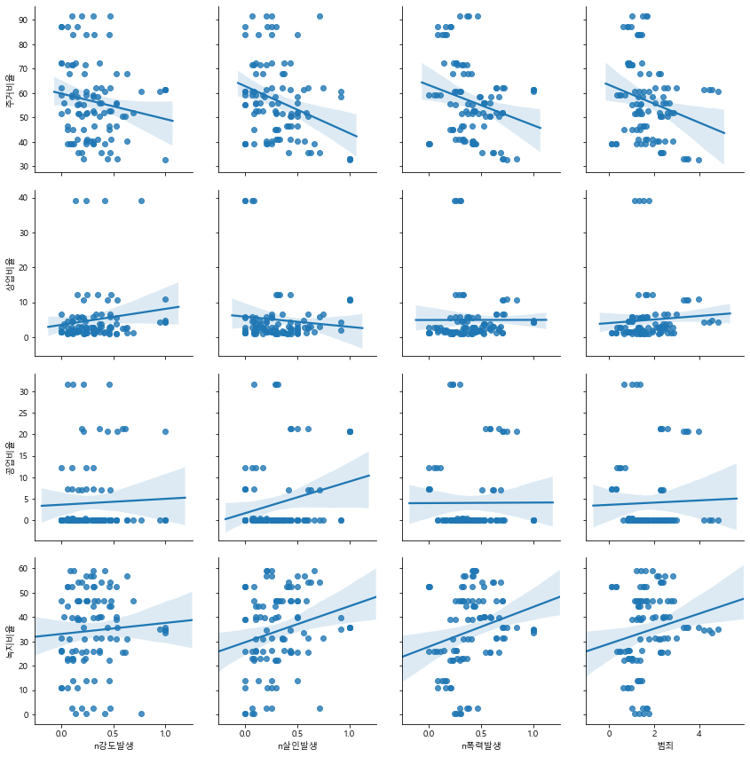

```python
sns.pairplot(n_crime,
             x_vars=['n강도발생','n살인발생','n폭력발생','범죄'],
             y_vars=['주거비율','상업비율','공업비율','녹지비율'],
            kind='reg',size=3)
plt.show()
```

- 전체적으로 범죄들이 주거비율과는 음의 상관관계, 녹지비율과는 양의 상관관계를 가짐
- 공업비율에 경우 살인발생에 관해서만 양의 상관관계를 가짐
  - 지역별 토지용도 데이터를 확인해 본 결과 공업비율이 높은구는 매우 적었음
  - 크게 의미를 두면 안될듯 함
- 토지비율은 1~2년 새에 변하기 쉽지 않은 변수이기 때문에 좀 더 넓은 기간을 두고 분석했어야 한다는 의견

### 생활만족도 별 범죄발생율 상관관계

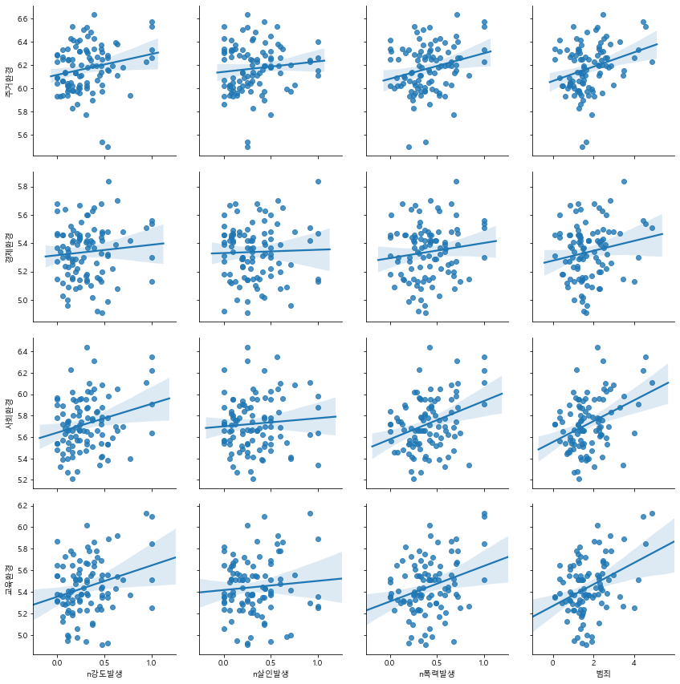

```python
sns.pairplot(n_crime,
             x_vars=['n강도발생','n살인발생','n폭력발생','범죄'],
             y_vars=['주거환경','경제환경','사회환경','교육환경'],
            kind='reg',size=3)
plt.show()
```

- 예상 외로 대부분의 만족도 변수가 범죄발생율과 양의 상관관계를 가짐
- 자료의 분포를 보면 강한 양의 상관관계라고는 할 수 없지만 예상과는 반대의 결과가 나옴
  - 실제 주민이 아닌 외부인으로 인한 범죄가 많을 가능성이 있음

### 토지비율과 범죄 검거율의 상관관계 시각화

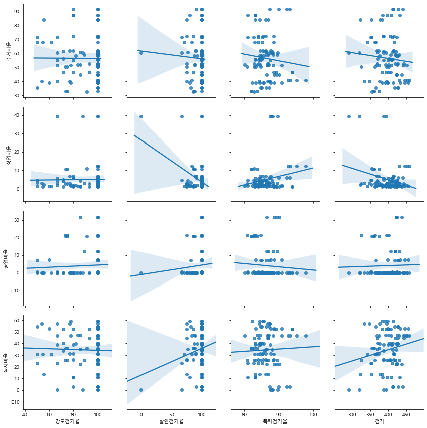

```python
sns.pairplot(n_crime,
             x_vars=['강도검거율','살인검거율','폭력검거율','검거'],
             y_vars=['주거비율','상업비율','공업비율','녹지비율'],
            kind='reg',size=3)
plt.show()
```

- 검거율과 토지비율과는 큰 상관관계가 없어보임
- 전년도에서 넘어온 범죄 떄문에 발생보다 검거 건수가 많은 경우가 생각보다 엄청 많았는데, 그걸 전부 100으로 처리했더니 분별력있는 정보가 나오지 않은듯 함